# Topic modeling - LDA and STM

Guided practice

In this guided practice we will learn how to train a LDA model in R using the State of the Union discourses.

## Loading libraries and data

```r
library(tidyverse)
library(tidytext)
library(topicmodels)
library(textclean)

data <- read_csv('data/state_ofthe_union_texts.csv')

data <- data %>% janitor::clean_names() # column names normalization

data <- data %>%
  filter(year >= 1934) # filter discourses from 1934

data <- data %>%
  mutate(id = row_number()) %>%
  select(id, everything())

data <- data %>% mutate(text = str_replace_all(text, "[:digit:]", ""))
#data <- data %>% mutate(text = str_replace_all(text, ". . . . .", ""))
data <- data %>% mutate(text = str_replace_all(text, "´", "'"))
data <- data %>% mutate(text = replace_contraction(text))
#data <- data %>% mutate(text = str_replace_all(text, "[:punct:]", ""))
data <- data %>% mutate(text = str_replace_all(text, "[\\[\\]]", ""))
data <- data %>% mutate(text = str_replace_all(text, "'", ""))
data <- data %>% mutate(text = str_replace_all(text, "\"", ""))
```

# Preprocessing

We will train LDA using unigrams:

```r
token_unigrams <- data %>%
  select(id, president, year, text) %>%
  unnest_tokens(word, text)

token_unigrams %>%
  group_by(id) %>%
  summarise(n=n())
```

| id | n |
| --- | --- |
| 1 | 2231 |
| 2 | 3522 |
| 3 | 3821 |
| 4 | 2740 |
| 5 | 4703 |
| 6 | 3778 |
| 7 | 3216 |
| 8 | 3325 |
| 9 | 3487 |
| 10 | 4586 |

[output cut: 72 more lines]

Notice that `unnest_tokens` took care of several preprocessing stages:

- Other columns, such as the line number each word came from, are retained.
- Punctuation has been stripped.
- By default, `unnest_tokens()` converts the tokens to lowercase, which makes them easier to compare or combine with other datasets. (Yo can use the `to_lower = FALSE` argument to turn off this behavior).

We can now eliminate stopwords (we added some custom stopwords):

```r
stop_words_data <- stop_words
stop_words_data <- stop_words_data %>%
  add_row(word = c('united', 'states', 'u. s.', 'u.s',
                   'program', 'programs',
                   'government', 'congress',
                   'applause', 'tonight', 'nation', 'nations', 'national',
                   'administration',
                   'country', 'americans',
                   'public', 'people', 'america', 'american', 'world'))

token_unigrams <- token_unigrams %>%
  anti_join(stop_words_data)
```

We generate the word count table.

```r
word_count <- token_unigrams %>%
  group_by(id, president, year, word) %>%
  summarise(n = n()) %>%
  ungroup()

word_count
```

| id | president | year | word | n |
| --- | --- | --- | --- | --- |
| 1 | Franklin Delano Roosevelt | 1934 | abolished | 1 |
| 1 | Franklin Delano Roosevelt | 1934 | accomplished | 1 |
| 1 | Franklin Delano Roosevelt | 1934 | accumulation | 1 |
| 1 | Franklin Delano Roosevelt | 1934 | acknowledging | 1 |
| 1 | Franklin Delano Roosevelt | 1934 | act | 4 |
| 1 | Franklin Delano Roosevelt | 1934 | action | 1 |
| 1 | Franklin Delano Roosevelt | 1934 | actual | 1 |
| 1 | Franklin Delano Roosevelt | 1934 | additional | 1 |
| 1 | Franklin Delano Roosevelt | 1934 | adequate | 1 |
| 1 | Franklin Delano Roosevelt | 1934 | adjustment | 1 |

[output cut: 9990 more lines]

## Formatting TFM

Our data frame word_counts is in a tidy form, with one-term-per-document-per-row. We need to transform it to a `DocumentTermMatrix`, the format required by `topicmodels` package. We can cast a one-token-per-row table into a `DocumentTermMatrix` with `tidytext`’s `cast_dtm()`.

```r
dtm <- word_count %>% cast_dtm(id, word, n)
```

## Train LDA

We can use the `LDA()` function from the topicmodels package, setting $k = 4$, to create a fairly simple four-topic LDA model.

```r
tictoc::tic()
lda <- LDA(dtm, k = 4, control = list(seed = 753))
tictoc::toc()
```

```
## 10.567 sec elapsed
```

This was the easy part. The main problem will be will involve exploring and interpreting the model using tidying functions from the `tidytext` package.

## Word-topic probabilities

The tidytext package offers a method to extract per-topic-per-word probabilities from the model, referred to as $\beta$ (“beta”).

```r
word2topics <- tidy(lda, matrix = "beta")
word2topics
```

| topic | term | beta |
| --- | --- | --- |
| 1 | abolished | 3.778926e-05 |
| 2 | abolished | 6.450733e-23 |
| 3 | abolished | 7.677989e-79 |
| 4 | abolished | 1.956906e-05 |
| 1 | accomplished | 3.812612e-04 |
| 2 | accomplished | 3.278008e-05 |
| 3 | accomplished | 2.182531e-04 |
| 4 | accomplished | 3.235497e-04 |
| 1 | accumulation | 8.496387e-05 |
| 2 | accumulation | 3.496694e-34 |

[output cut: 9990 more lines]

Let’s find the most frequent terms for each topic and make a nice plot:

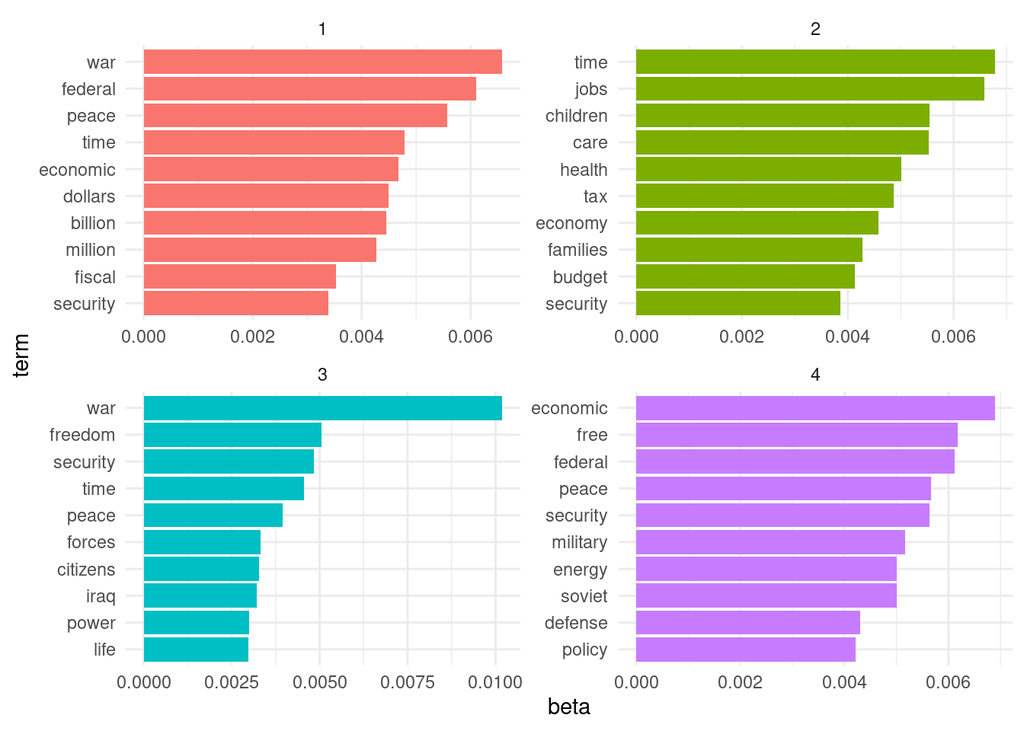

```r
top_terms <- word2topics %>%
  group_by(topic) %>%
  slice_max(beta, n = 10) %>%
  ungroup() %>%
  arrange(topic, -beta)

top_terms %>%
  mutate(term = reorder_within(term, beta, topic)) %>%
  ggplot(aes(beta, term, fill = factor(topic))) +
  geom_col(show.legend = FALSE) +
  facet_wrap(~ topic, scales = "free") +
  scale_y_reordered() +
  theme_minimal()
```

## Document-topic probabilities

LDA also allows us to model documents as a mixture of topics. We can analyze the document-topic probabilities matrix using `tidy()` and setting `matrix="gamma"`.

```r
doc2topics <- tidy(lda, matrix="gamma")
doc2topics %>%
  mutate(document=as.numeric(document)) %>%
  arrange(document, topic, desc(gamma))
```

| document | topic | gamma |
| --- | --- | --- |
| 1 | 1 | 9.998157e-01 |
| 1 | 2 | 6.142944e-05 |
| 1 | 3 | 6.142944e-05 |
| 1 | 4 | 6.142944e-05 |
| 2 | 1 | 9.619024e-01 |
| 2 | 2 | 4.062687e-05 |
| 2 | 3 | 4.062687e-05 |
| 2 | 4 | 3.801634e-02 |
| 3 | 1 | 5.644273e-01 |
| 3 | 2 | 4.014253e-05 |

[output cut: 318 more lines]

### Visualizing and interpreting topics

Until now, we have used the probabilities of each word belonging to each topic as a way to interpret what each topic is about. However, as mentioned above, there are several words that repeat across more than one topic (“war,” “peace,” “federal”) and, moreover, they appear with high probabilities of belonging to each one. Other words seem to belong more exclusively to a certain topic.

It would be useful, then, to be able to differentiate words according to some metric that gives us an idea of the importance of each word in each topic and that does not take into account or “discount” the relevance of each word over the total corpus. That is the function of the relevance metric $r$ (Sievert and Shirley 2014).

$$r(w,k|\lambda) = \lambda log(\phi_{kw})
+ (1-\lambda) log(\frac{\phi_{kw}}{p_{w}})$$
The relevance of a word $w$ within a topic $k$ ($r(kw|\lambda)$) is a function of the logarithms of the probability of $w$ belonging to $k$ ($\phi_{kw}$) and the lift, that is, the ratio between that probability and the marginal probability of each $w$ in the total corpus ($\frac{\phi_{kw}}{p_{w}}$). In turn, there is an adjustment parameter $\lambda$ that serves to control the weight of each component in the total metric. Thus, $\lambda=0$ only ranks the words based on the lift. On the other hand, $\lambda=1$ generates the metric we have worked with so far and allows ranking the words based on their probability of belonging to the topic.

Fortunately, there is a library that allows us to visualize all this information in a graphical and quite useful way.

#### LDAvis

Let’s load `LDAvis`:

```r
library(LDAvis)
```

```r
topicmodels_json_ldavis <- function(fitted, word_count){
  # Find required quantities
  ## Generates word2topic matrix
    phi <- tidy(lda, "beta") %>%
      pivot_wider(names_from = term,
                  values_from = beta) %>%
      column_to_rownames(var="topic") %>%
      as.matrix()

  ## Generates doc2topic matrix
    theta <- tidy(lda, "gamma") %>%
      pivot_wider(names_from = topic,
                  values_from = gamma) %>%
      column_to_rownames(var="document") %>%
      as.matrix()

  ## Generates vocabulary
    vocab <- colnames(phi)

  ## Generates document length vector
    doc_length <- word_count %>%
      group_by(id) %>%
      summarise(n=sum(n)) %>%
      select(n) %>%
      pull()

  ## Generates marginal distribution of terms
    term_freq <- word_count %>%
      group_by(word) %>%
      summarise(n = sum(n))

  ## Function to correct a zeros error in LDAvis when K=2
     svd_tsne <- function(x) tsne::tsne(svd(x)$u)

  ## Convert to json
    json_lda <- LDAvis::createJSON(phi = phi, theta = theta,
                            vocab = vocab,
                            doc.length = doc_length,
                            term.frequency = term_freq$n,
                            mds.method = svd_tsne
                            )

    return(json_lda)
}

json_vis <- topicmodels_json_ldavis(lda, word_count)
serVis(json_vis, out.dir = "../17_topic_modeling/vis", open.browser = FALSE)
```

Unfortunately, we cannot embed the dashboard in the .rmd file, so we will only use a snapshot here. If you go to the ‘Plots’ tab, you will be able to see the dashboard in interactive format.

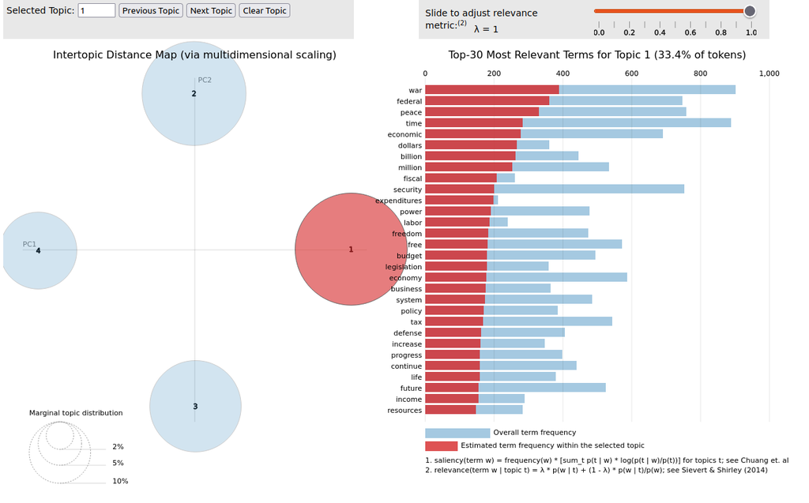

The left panel provides information about two important questions:

- How prevalent is each topic?
- How do the topics relate to each other?

The relative position in a two-dimensional space of the mentioned $k$ topics is projected. Different methods can be used for this purpose (PCA, t-SNE). Each topic is represented as a circle. In this case, t-SNE has been used. It can be observed that the circles are fairly separated from each other.

Furthermore, the area of the circles is proportional to the relevance of the topic in the overall corpus. Thus, in our case, topics 1, 2, and 3 represent 77.5% of the corpus.

But if we modify the slider to $\lambda=0.5$, this list changes:

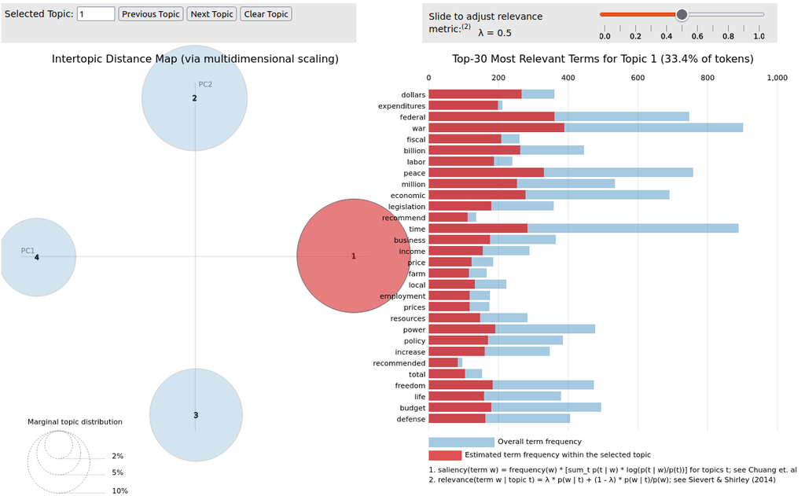

You can try what happens with the other topics. Do their interpretations change when varying the metric to order the terms in each topic?

## Structural Topic Modeling (STM)

The last technique we are going to review in this guided practice is STM. As we mentioned earlier, its main use is to allow the introduction of covariates in topic modeling and to enable topics (either their prevalence or content) to vary based on external variables or metadata.

To implement it, the `stm` library is required:

```r
library(stm)
```

The usage is similar to the previous case. We just need to transform the tibble `word_count` into another object, a `dfm`:

```r
dfm <- word_count %>%
                cast_dfm(id, word, n)

head(dfm)
```

```
## Document-feature matrix of: 6 documents, 14,073 features (94.43% sparse) and 0 docvars.
##     features
## docs abolished accomplished accumulation acknowledging act action actual
##    1         1            1            1             1   4      1      1
##    2         0            1            0             0   5      1      1
##    3         0            1            0             0   1      2      0
##    4         0            0            0             0   2      9      1
##    5         0            1            0             0   0      2      1
##    6         0            1            0             0   2      4      0
##     features
## docs additional adequate adjustment
##    1          1        1          1
##    2          2        2          2
##    3          0        1          1
##    4          0        2          0
##    5          1        4          0
##    6          0        2          0
## [ reached max_nfeat ... 14,063 more features ]
```

Then, we can generate a tibble with the metadata we are going to use later:

```r
metadata <- token_unigrams %>%
                  select(id, president, year) %>%
                  distinct() %>%
                  left_join(data %>% select(id, text))
```

And then, we call the `stm` function. We are going to use the year of the speech as a variable that affects the prevalence.

```r
stm_4 <- stm(documents = dfm,
      K = 4,
      prevalence = ~year,
      max.em.its = 75,
      data = metadata,
      init.type = "Spectral")
```

```
## Beginning Spectral Initialization
##   Calculating the gram matrix...
##   Using only 10000 most frequent terms during initialization...
##   Finding anchor words...
##      ....
##   Recovering initialization...
##      ....................................................................................................
## Initialization complete.
## ..................................................................................
## Completed E-Step (0 seconds).
## Completed M-Step.
## Completing Iteration 1 (approx. per word bound = -8.189)
## ..................................................................................
## Completed E-Step (0 seconds).
## Completed M-Step.
## Completing Iteration 2 (approx. per word bound = -7.905, relative change = 3.459e-02)
## ..................................................................................
## Completed E-Step (0 seconds).
## Completed M-Step.
## Completing Iteration 3 (approx. per word bound = -7.886, relative change = 2.490e-03)
## ..................................................................................
## Completed E-Step (0 seconds).
## Completed M-Step.
## Completing Iteration 4 (approx. per word bound = -7.879, relative change = 8.464e-04)
## ..................................................................................
## Completed E-Step (0 seconds).
## Completed M-Step.
## Completing Iteration 5 (approx. per word bound = -7.875, relative change = 4.802e-04)
## Topic 1: time, children, care, health, budget
##  Topic 2: war, dollars, million, peace, time
##  Topic 3: free, peace, economic, federal, security
##  Topic 4: energy, security, jobs, economy, time
## ..................................................................................
## Completed E-Step (0 seconds).
## Completed M-Step.
## Completing Iteration 6 (approx. per word bound = -7.873, relative change = 3.222e-04)
## ..................................................................................
## Completed E-Step (0 seconds).
## Completed M-Step.
## Completing Iteration 7 (approx. per word bound = -7.871, relative change = 2.426e-04)
```

[output cut: 57 more lines]

```
## Completed E-Step (0 seconds).
## Completed M-Step.
## Completing Iteration 20 (approx. per word bound = -7.864, relative change = 1.208e-05)
## Topic 1: time, children, care, health, budget
##  Topic 2: war, dollars, million, peace, time
##  Topic 3: federal, economic, peace, free, security
##  Topic 4: jobs, energy, security, economy, time
## ..................................................................................
## Completed E-Step (0 seconds).
## Completed M-Step.
## Completing Iteration 21 (approx. per word bound = -7.864, relative change = 1.089e-05)
## ..................................................................................
## Completed E-Step (0 seconds).
## Completed M-Step.
## Model Converged
```

If we wanted to vary the content, we would just need to pass the parameter content with the covariate:

```
content = ~year
```

We generate the same two basic matrices as in LDA:

```r
betas_stm <- tidy(stm_4, matrix='beta')
doc_2_topics_stm <- tidy(stm_4, matrix='theta')
```

And we can plot the results:

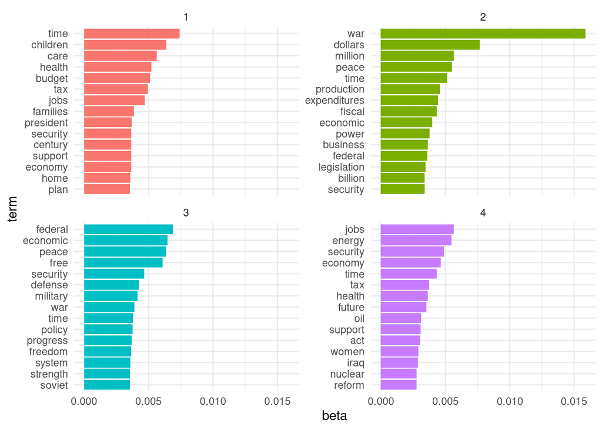

```r
 betas_stm %>%
  group_by(topic) %>%
  slice_max(beta, n = 15) %>%
  ungroup() %>%
  arrange(topic, -beta) %>%
  mutate(term = reorder_within(term, beta, topic)) %>%
  ggplot(aes(beta, term, fill = factor(topic))) +
  geom_col(show.legend = FALSE) +
  facet_wrap(~ topic, scales='free_y') +
  scale_y_reordered() +
  theme_minimal()
```

### Some useful tools in STM

Now, once we have estimated our STM topic model, it is extremely important to proceed with its validation. Let’s see that the stm package has implemented some functions that make this validation task quite easy.

Let’s explore two possible ways to proceed with model validation. The first one is to analyze the words that are part of each topic. This is similar to what we have been doing so far, but with a difference: until now, we had been working with the words that have the highest β, that is, the highest probability of belonging to each topic. STM allows us to obtain other lists of words. Let’s call the following function:

```r
labelTopics(stm_4)
```

```
## Topic 1 Top Words:
##       Highest Prob: time, children, care, health, budget, tax, jobs
##       FREX: crime, parents, st, century, college, family, children
##       Lift: aaron, abess, abm, absent, accessibility, acquisitions, ad
##       Score: medicare, internet, brady, parents, students, bosnia, environment
## Topic 2 Top Words:
##       Highest Prob: war, dollars, million, peace, time, production, expenditures
##       FREX: estimated, liquidation, japanese, receipts, expenditures, navy, reconversion
##       Lift: aaa, abdicated, ablaze, ably, abnormal, abovementioned, absentee
##       Score: liquidation, reconversion, demobilization, expenditures, hitler, autocracy, vj
## Topic 3 Top Words:
##       Highest Prob: federal, economic, peace, free, security, defense, military
##       FREX: communists, soviet, communist, relations, aggression, atomic, assistance
##       Lift: a.d, abating, abridges, abrupt, absorbs, absurd, accelerates
##       Score: communists, communist, xa, recommend, disarmament, partnership, postal
## Topic 4 Top Words:
##       Highest Prob: jobs, energy, security, economy, time, tax, health
##       FREX: let’s, we’ve, that’s, can’t, it’s, i’m, iraqis
##       Lift: a.s, abbas, abortions, abstinence, abusing, accessing, accumulates
##       Score: that’s, it’s, terrorists, we’ve, i’m, let’s, qaeda
```

This output shows four lists of words. Let’s focus on the first two:

- Highest prob: These are the words within each topic with the highest probability (directly inferred from the topic-word distribution parameter β). These are the ones we used in the plots above.
- FREX: This is a metric that attempts to combine frequency (β) with exclusivity. In other words, words with high FREX are distinctive words for topics: they are both frequent and exclusive. This is calculated by taking the harmonic mean of the rank by probability within the topic (frequency, i.e., the parameter β), and exclusivity is a measure that tries to quantify the relative use of a term in a topic compared to its use in other topics.

Thus, the distribution of words according to FREX in topic 4 shows that some contractions survived without expansion (“let’s,” “we’ve,” etc.). However, “iraqis” is a relevant term.

To examine documents that are highly associated with topics, the findThoughts() function can be used. This function will print out the documents highly associated with each topic. Reading these documents is useful for understanding the content of a topic and interpreting its definition.

To make them easier to read, let’s limit them to a few characters of each document.

```r
findThoughts(stm_4,
             texts= metadata %>% mutate(text = str_sub(text, 200, 600)) %>% select(text) %>% pull(),
             n=10,
             topics=4)
```

```
##
##  Topic 4:
##        try to make it shorter. I know some of you are antsy to get back to Iowa. I have been there. I will be shaking hands afterwards if you want some tips., Now I understand that because it’s an election season, expectations for what we’ll achieve this year are low. But Mr. Speaker, I appreciat…
##      d welcomed home some of our last troops to serve in Iraq. Together, we offered a final, proud salute to the colors under which more than a million of our fellow citizens fought, and several thousand gave their lives.  We gather tonight knowing that this generation of heroes has made the Unit…
##       his day, the late Congressman Thomas DAlesandro, Jr. from Baltimore, Maryland, saw Presidents Roosevelt and Truman at this rostrum. But nothing could compare with the sight of his only daughter, Nancy, presiding tonight as Speaker of the House of Representatives. (Applause.) Congratulations…
##      te to its highest level in more than three decades., An entrepreneur flipped on the lights in her tech startup, and did her part to add to the more than eight million new jobs our businesses have created over the past four years., An autoworker fine-tuned some of the best, most fuel-efficien…
##      ather in this chamber deeply aware of decisive days that lie ahead., You and I serve our country in a time of great consequence. During this session of Congress, we have the duty to reform domestic programs vital to our country; we have the opportunity to save millions of lives abroad from a…
##      me, our country has been tested in ways none of us could have imagined. We faced hard decisions about peace and war, rising competition in the world economy, and the health and welfare of our citizens. These issues call for vigorous debate, and I think it is fair to say we have answered the …
##      ageous woman who called America to its founding ideals and carried on a noble dream. Tonight we are comforted by the hope of a glad reunion with the husband who was taken from her so long ago, and we are grateful for the good life of Coretta Scott King., Each time I am invited to this rostru…
##      ffice by the votes of the people we serve. And tonight that is a privilege we share with newly-elected leaders of Afghanistan, the Palestinian Territories, Ukraine, and a free and sovereign Iraq., Two weeks ago, I stood on the steps of this Capitol and renewed the commitment of our nation to…
##      , As we gather tonight, hundreds of thousands of American servicemen and women are deployed across the world in the war on terror. By bringing hope to the oppressed, and delivering justice to the violent, they are making America more secure., Each day, law enforcement personnel and intellige…
##      ivilized world faces unprecedented dangers. Yet the state of our Union has never been stronger., We last met in an hour of shock and suffering. In four short months, our nation has comforted the victims, begun to rebuild New York and the Pentagon, rallied a great coalition, captured, arreste…
```

It is observed that several of the texts do indeed refer to the invasion of Iraq and other conflicts.

Sievert, Carson, and Kenneth Shirley. 2014. “LDAvis: A Method for Visualizing and Interpreting Topics.” In *Proceedings of the Workshop on Interactive Language Learning, Visualization, and Interfaces*, edited by Jason Chuang, Spence Green, Marti Hearst, Jeffrey Heer, and Philipp Koehn, 63–70. Baltimore, Maryland, USA: Association for Computational Linguistics. https://doi.org/10.3115/v1/W14-3110.

Silge, Julia, and David Robinson. 2017. *Text Mining with r: A Tidy Approach*. 1st ed. O’Reilly Media, Inc.